# NoteBook Perceptron KNN Perros Gatos

##### Realizado por:

- **Nestor Jardany Serrano Rojas**, [GitHub](https://github.com/jardanys/Saber_11_AreaTemporal)

## Perceptron para Sexo ~ Peso + Estatura

En Machine Learning es un algoritmo capaz de generar un criterio para seleccionar un sub-grupo a partir de un grupo de componentes más grande. Para este capitulo del NoteBook se utiliza una base de datos muestra con diferentes variables sociodemográficas como **Edad**, **Peso**, **Estatura**, tomadas de un grupo de estudiantes. Para determinar el genero a partir de la estatura y peso.

Es necesario normalizar o estandarizar las variables con el fin de tener una mejor clasificación del algoritmo y análisis de los resultados. También se asignan valores de **1** para el la variable [Sexo]=Masculino y **0** para [Sexo]=Femenino.

```r
X <- readRDS("X.rds")
X[,c(2:3)] <- X[,c(2,3)]/100
X$G <- substr(X$Sexo, 1, 1)
X$g <- as.numeric(X$G=="M")
X$Uno <- 1
```

Se crea una función llamada f para asignar el valor de **1** si un valor de x es mayor a cero o **0** sino una valor de x no es mayor a 0. La variable [l] es el número de filas o registros del archivo.

```r
f <- function(x){
  if(x>0) return(1)
  return(0)
}

l <- nrow(X)
```

El objetivo del ejercicio es clasificar la variable [Sexo] a partir de las variables [Peso] y [Estatura]. A continuación se muestra gráficamente la distribución de [Sexo] a partir de los valores de las otras variables.

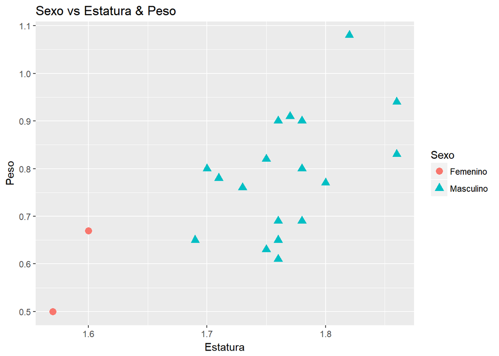

A continuación se muestra el algoritmo del perceptron, se escoge la linea que mejor representa los datos:

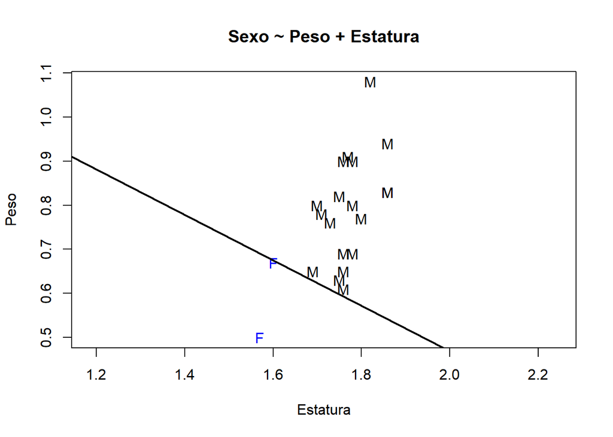

```r
plot(X$Estatura, X$Peso, type = "n", xlab="Estatura", ylab="Peso",asp=1, main="Sexo ~ Peso + Estatura")
cols <- rep("blue",nrow(X))
cols[which(X$G=="M")] <- "black"
text(X$Estatura, X$Peso, X$G, col=cols)

while(!done){
  ind <- sample(1:l,1)
  h <- f(sum(w*X[ind,c(2,3,9)]))
  w <- w + (X$g[ind] - h) * unlist(X[ind,c(2,3,9)])
  a <- -w[3]/w[2]
  b <- -w[1]/w[2]
  rr <- NULL
  for(i in 1:l){
    r <- ifelse((X[i,3] < X[i,2]*b + a & X[i,8] == 0) | (X[i,3] > X[i,2]*b + a & X[i,8] == 1),1,0)
    rr <- rbind(rr, r)
    err <- 1 - sum(rr)/l
  }
  z <- rbind(z, c(iter, a, b, err))
  iter <- iter + 1
  if(iter >= max.iter) done <- TRUE
}

iter_err_min <- order(z[,4], decreasing = F)[1]
abline(z[iter_err_min,2],z[iter_err_min,3],col="black",lwd=2)
```

```r
zz <- as.data.frame(z[-1,])
```

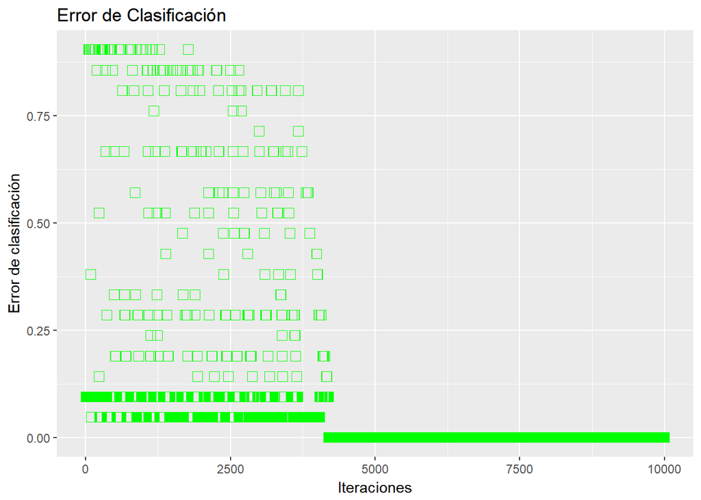

## Perceptron para Peso ~ Edad + Estatura

Para este capitulo del NoteBook se utiliza una base de datos muestra con diferentes variables sociodemográficas como **Edad**, **Peso**, **Estatura**, tomadas de un grupo de estudiantes. Para determinar si las personas tienen un peso superior a media a partir de la edad y estatura.

Se asignan valores de **1** para el la variable [Peso] >= mean(Peso) y **0** para [Peso] < mean(Peso).

El objetivo del ejercicio es clasificar la variable [Peso] a partir de las variables [Edad] y [Estatura]. A continuación se muestra gráficamente la distribución de [Peso] a partir de los valores de las otras variables.

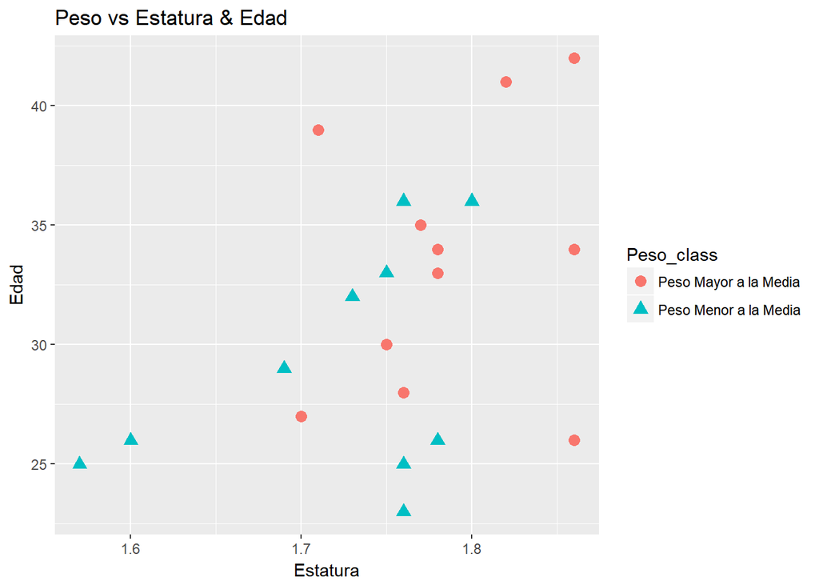

A continuación se muestra el algoritmo del perceptron, se escoge la linea que mejor representa los datos:

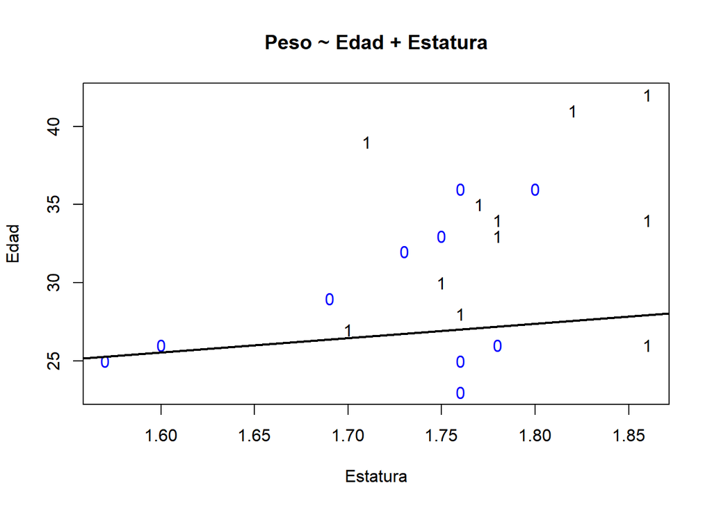

```r
while(!done){
  ind <- sample(1:l,1)
  h <- f(sum(w*X[ind,c(2,1,9)]))
  w <- w + (X$g[ind] - h) * unlist(X[ind,c(2,1,9)])
  a <- -w[3]/w[2]
  b <- -w[1]/w[2]
  rr <- NULL
  for(i in 1:l){
    r <- ifelse((X[i,1] < X[i,2]*b + a & X[i,7] == 0) | (X[i,1] > X[i,2]*b + a & X[i,7] == 1),1,0)
    rr <- rbind(rr, r)
    err <- 1 - sum(rr)/l
  }
  z <- rbind(z, c(iter, a, b, err))
  iter <- iter + 1
  if(iter >= max.iter) done <- TRUE
}
iter_err_min <- order(z[,4], decreasing = F)[4]
plot(X$Estatura, X$Edad, type = "n", xlab="Estatura", ylab="Edad",  main="Peso ~ Edad + Estatura")
cols <- rep("blue",nrow(X))
cols[which(X$G==1)] <- "black"
text(X$Estatura, X$Edad, X$G, col=cols)
abline(z[iter_err_min,2],z[iter_err_min,3],col="black",lwd=2)
```

```r
zz <- as.data.frame(z[-1,])
```

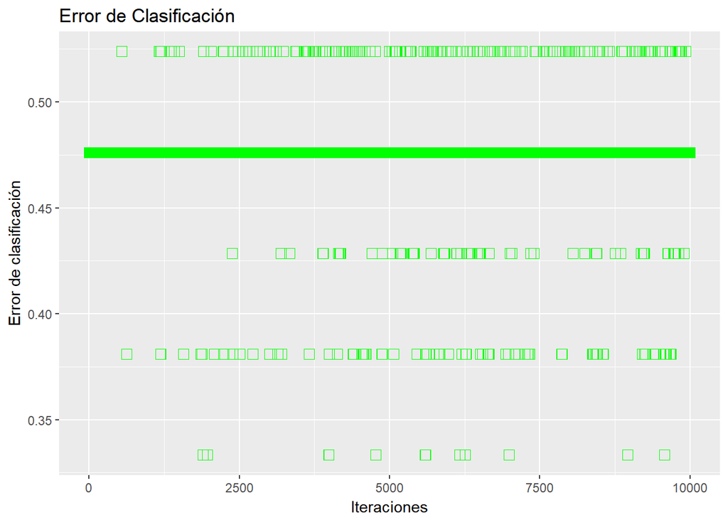

## KNN (k-nearest neighbors). Sexo ~ Peso + Estatura

Estimación de Sexo a aprtir del peso y estatura.

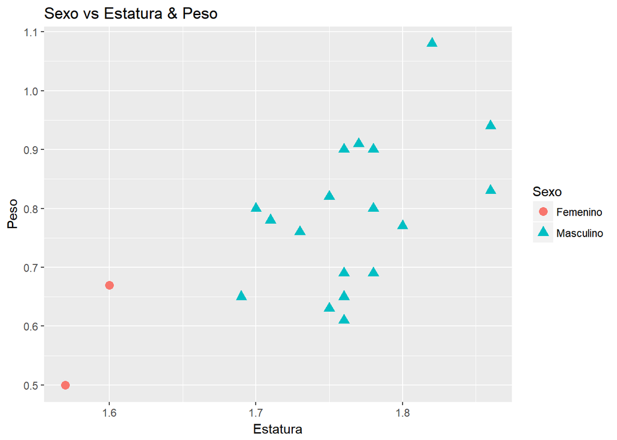

Límites de simulación basados en peso y estatura

```r
lims <- c(1, 2.5, 0, 1.5)
nuevopunto <- function(lims=lims){
  a <- runif(1,lims[1],lims[2])
  b <- runif(1,lims[3],lims[4])
  return(c(a, b))
}
```

Se gráfica y se muestra el resultado para KNN

con K=1

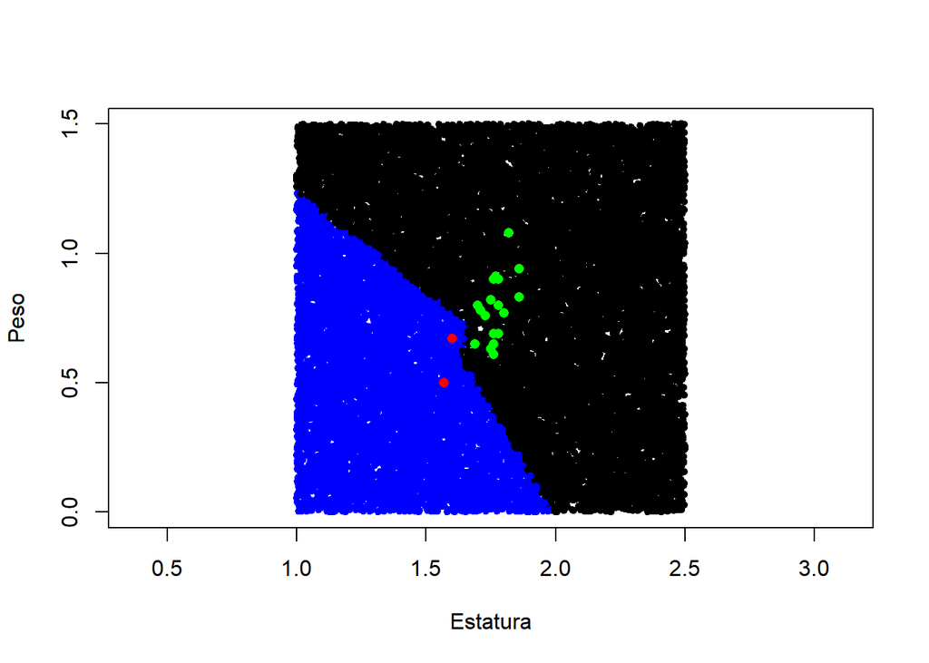

```r
k <- 1
plot(X$Estatura, X$Peso, type = "n", xlab="Estatura", ylab="Peso",asp=1,
xlim=c(1,2.5),ylim=c(0,1.5))
cols <- rep("blue",nrow(X))
cols[which(X$G=="M")] <- "black"
points(X$Estatura, X$Peso, pch=16, col=cols)
for(iter in 1:20000){
  x <- nuevopunto(lims)
  diss <- dist(rbind(x,X[,c(2,3)]))[1:21]
  knn <- head(order(diss),k)
  etiqueta <- names(sort(table(X$G[knn]),decreasing = TRUE))[1]
  clase <- as.numeric(etiqueta=="M")
  for(inn in 1:k){
    if(X$G[knn[inn]]==etiqueta){
      points(x[1],x[2],col=c("blue","black")[clase+1],pch=20)
    }
  }
}

cols2 <- rep("red",nrow(X))
cols2[which(X$G=="M")] <- "green"
points(X$Estatura, X$Peso, pch=16, col=cols2)
```

con K=2

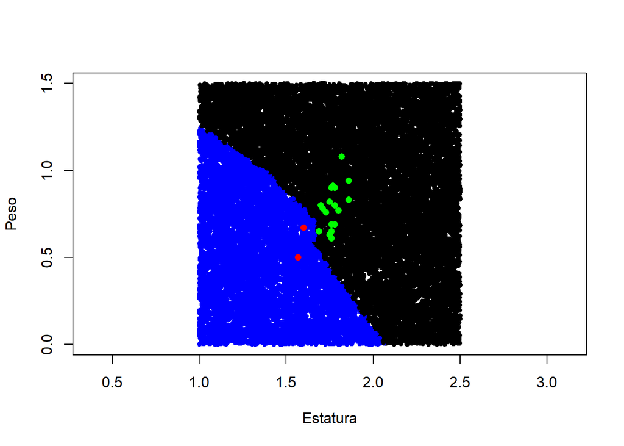

```r
k <- 2
plot(X$Estatura, X$Peso, type = "n", xlab="Estatura", ylab="Peso",asp=1,
xlim=c(1,2.5),ylim=c(0,1.5))
cols <- rep("blue",nrow(X))
cols[which(X$G=="M")] <- "black"
points(X$Estatura, X$Peso, pch=16, col=cols)
for(iter in 1:20000){
  x <- nuevopunto(lims)
  diss <- dist(rbind(x,X[,c(2,3)]))[1:21]
  knn <- head(order(diss),k)
  etiqueta <- names(sort(table(X$G[knn]),decreasing = TRUE))[1]
  clase <- as.numeric(etiqueta=="M")
  for(inn in 1:k){
    if(X$G[knn[inn]]==etiqueta){
      points(x[1],x[2],col=c("blue","black")[clase+1],pch=20)
    }
  }
}

cols2 <- rep("red",nrow(X))
cols2[which(X$G=="M")] <- "green"
points(X$Estatura, X$Peso, pch=16, col=cols2)
```

con K=3

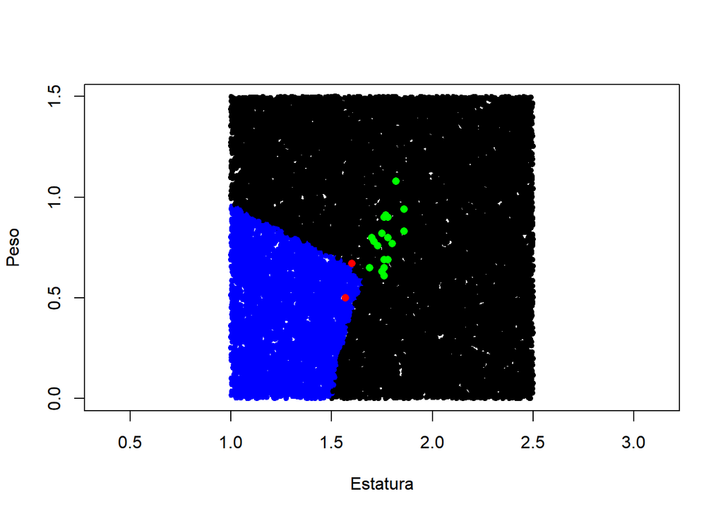

```r
k <- 3
plot(X$Estatura, X$Peso, type = "n", xlab="Estatura", ylab="Peso",asp=1,
xlim=c(1,2.5),ylim=c(0,1.5))
cols <- rep("blue",nrow(X))
cols[which(X$G=="M")] <- "black"
points(X$Estatura, X$Peso, pch=16, col=cols)
for(iter in 1:20000){
  x <- nuevopunto(lims)
  diss <- dist(rbind(x,X[,c(2,3)]))[1:21]
  knn <- head(order(diss),k)
  etiqueta <- names(sort(table(X$G[knn]),decreasing = TRUE))[1]
  clase <- as.numeric(etiqueta=="M")
  for(inn in 1:k){
    if(X$G[knn[inn]]==etiqueta){
      points(x[1],x[2],col=c("blue","black")[clase+1],pch=20)
    }
  }
}

cols2 <- rep("red",nrow(X))
cols2[which(X$G=="M")] <- "green"
points(X$Estatura, X$Peso, pch=16, col=cols2)
```

## Caso de Uso Perro & Gatos

Se tiene una base de datos con los pixeles de 198 animales, 99 gatos y 99 perros. Se carga la base y se crea una función para gráficar los animales. A continuación se muestra un ejemplo de un animal de la base.

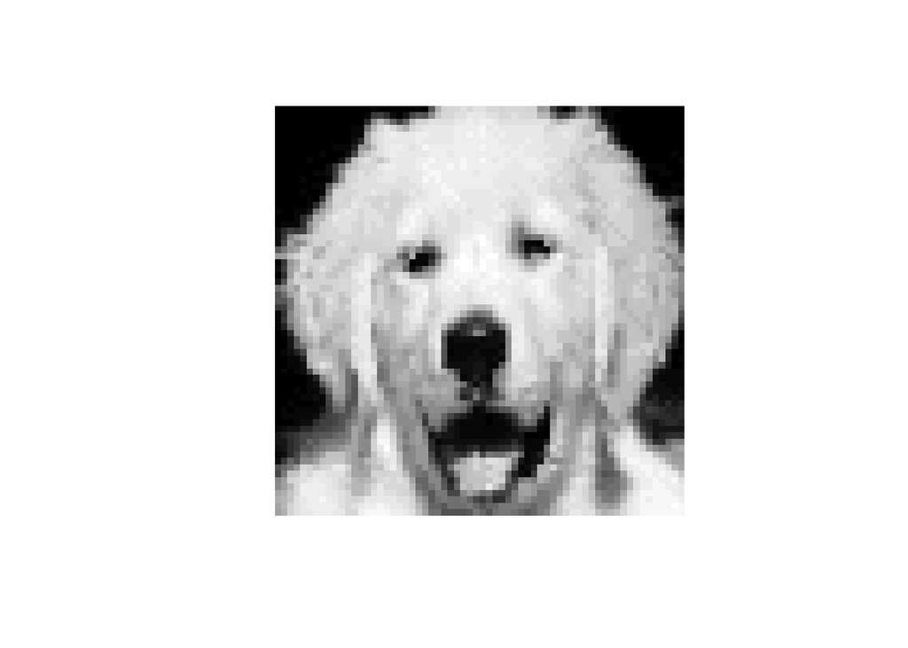

```r
load("gatosperros.Rdata")
plotcd <- function(v){
  x <- matrix(v,64,64)
  image(1:65,1:65,t(apply(x,2,rev)),asp=1,xaxt="n",yaxt="n",
        col=grey((0:255)/255),ann=FALSE,bty="n")
}
plotcd(dm[sample(1:198,1),])
```

### PCA - Perros & Gatos

Se realiza un PCA (Clasificación por componentes principales), se puede observar que se tiene el 50% con cuatro componentes y el 80% con el 80% con 27 componentes.

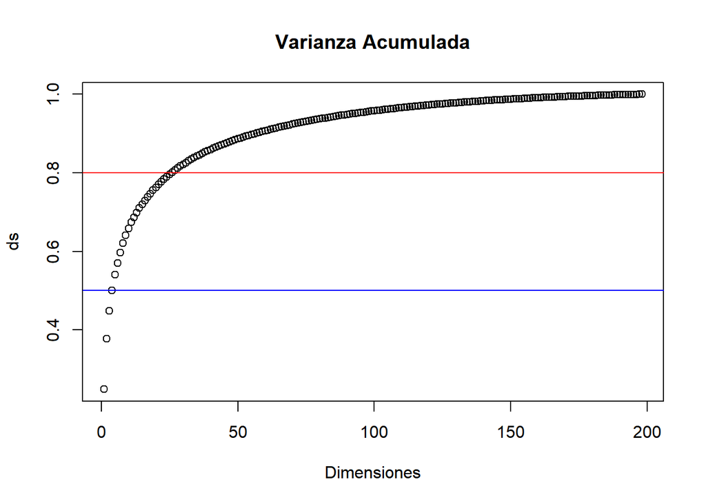

```r
PCA <- prcomp(dm, scale = TRUE)
plot(cumsum(PCA$sdev^2)/sum(PCA$sdev^2), xlab = "Dimensiones", ylab = "ds", main = "Varianza Acumulada")
abline(h=0.5, col="blue")
abline(h=0.8, col="red")
```

A continuación se muestra en dos componentes la distribución de los perros y gatos.

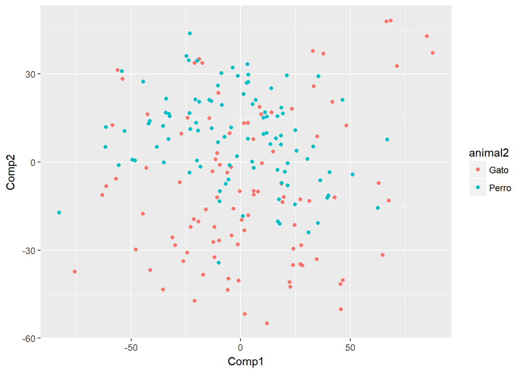

```r
dos_dim <- data.frame("Comp1" = PCA$x[,1], "Comp2" = PCA$x[,2])
dos_dim$animal <- c(rep(1,99), rep(0, 99))
dos_dim$animal2 <- ifelse(dos_dim$animal==1, "Gato", "Perro")
ggplot(dos_dim, aes(Comp1, Comp2)) + geom_point(aes(colour=animal2))
```

2018-04 Universidad Santo Tomas

Copyright © All rights reserved.